# Exercise 3

26/03/2020

Importing the requisite libraries

```r
library(tidyverse)
library(kernlab)
library(dbscan)
library(clValid) # For selecting cluster method and number of clusters
library(factoextra) # for cluster fitting and visualization
library(uwot) # For UMAP dimensionality reduction
```

```r
library(patchwork) # For arranging multiple plots
set.seed(888) # To ensure consistent results from non-deterministic procedures
```

compas.df is our data For cluster analysis only numeric data can be used , hence all columns of type categorical,date, etc.other than numeric were removed. Removed outcome columns like decile_score,recidivinism rate, v_decile_score,etc. The selected_data is the final data , after filtering, which will be used for clustering.

```r
compas.df = read_csv("https://raw.githubusercontent.com/propublica/compas-analysis/master/compas-scores.csv")
#compas.df%>% skimr::skim()
k=drop_na(compas.df,days_b_screening_arrest,c_offense_date,r_charge_desc,r_jail_in,days_b_screening_arrest,c_charge_desc)#removing missing rows
k2=k%>% select(-vr_offense_date,-vr_charge_desc,-num_vr_cases,-vr_case_number,-vr_charge_degree,-c_arrest_date,-num_r_cases)
k3=k2%>%select(age,juv_fel_count,juv_misd_count,juv_other_count,priors_count,days_b_screening_arrest,c_days_from_compas,r_days_from_arrest)

selected_data=k3%>%sample_n(size = 400)%>%scale() %>% as.data.frame()
selected_data %>% skimr::skim()
```

Data summary

| Name | Piped data |
| --- | --- |
| Number of rows | 400 |
| Number of columns | 8 |
| _______________________ |  |
| Column type frequency: |  |
| numeric | 8 |
| ________________________ |  |
| Group variables | None |

**Variable type: numeric**

| skim_variable | n_missing | complete_rate | mean | sd | p0 | p25 | p50 | p75 | p100 | hist |
| --- | --- | --- | --- | --- | --- | --- | --- | --- | --- | --- |
| age | 0 | 1 | 0 | 1 | -1.19 | -0.76 | -0.32 | 0.46 | 5.49 | ▇▂▁▁▁ |
| juv_fel_count | 0 | 1 | 0 | 1 | -0.23 | -0.23 | -0.23 | -0.23 | 10.73 | ▇▁▁▁▁ |
| juv_misd_count | 0 | 1 | 0 | 1 | -0.19 | -0.19 | -0.19 | -0.19 | 14.29 | ▇▁▁▁▁ |
| juv_other_count | 0 | 1 | 0 | 1 | -0.27 | -0.27 | -0.27 | -0.27 | 11.85 | ▇▁▁▁▁ |
| priors_count | 0 | 1 | 0 | 1 | -0.86 | -0.67 | -0.31 | 0.43 | 4.82 | ▇▂▁▁▁ |
| days_b_screening_arrest | 0 | 1 | 0 | 1 | -3.27 | -0.17 | -0.17 | -0.15 | 9.02 | ▁▇▁▁▁ |
| c_days_from_compas | 0 | 1 | 0 | 1 | -0.15 | -0.15 | -0.15 | -0.15 | 17.45 | ▇▁▁▁▁ |
| r_days_from_arrest | 0 | 1 | 0 | 1 | -0.27 | -0.26 | -0.26 | -0.24 | 10.50 | ▇▁▁▁▁ |

#Things i learnt Connectivity-Calculates the connectivity validation measure for a given cluster partitioning.The value of connectivity is between 0 and infinity, and should be minimized.

Dunn index-The Dunn Index is the ratio of the smallest distance between observations not in the same cluster to the largest intra-cluster distance. The Dunn Index has a value between zero and infinity, and should be maximized.

The Silhouette Width - It is the average of each observation’s Silhouette value. The Silhouette value measures the degree of confidence in the clustering assignment of a particular observation, with well-clustered observations having values near 1 and poorly clustered observations having values near −1.

```r
internal.cl = clValid(selected_data,
                  nClust = 2:10,
                  clMethods = c("kmeans","pam", "agnes", "diana"),
                  maxitems = 1000, # specifies the number of cases considered
                  validation = "internal")
## View internal metrics
summary(internal.cl)
```

```
##
## Clustering Methods:
##  kmeans pam agnes diana
##
## Cluster sizes:
##  2 3 4 5 6 7 8 9 10
##
## Validation Measures:
##                             2        3        4        5        6        7        8        9       10
##
## kmeans Connectivity    2.9290   9.7159  28.3853  28.3853  32.8933  39.0663  40.7036  45.8115  88.3833
##        Dunn            0.5807   0.4533   0.1614   0.1861   0.0657   0.0967   0.0967   0.1013   0.0182
##        Silhouette      0.8336   0.7835   0.5341   0.5357   0.5482   0.5270   0.5295   0.4881   0.3783
## pam    Connectivity   95.4099 137.0222 185.3040 171.1734 156.7020 151.7734 126.2611 129.5290 130.8052
##        Dunn            0.0041   0.0037   0.0047   0.0048   0.0048   0.0049   0.0047   0.0049   0.0079
##        Silhouette      0.2583   0.2325   0.1066   0.1226   0.1294   0.1815   0.2202   0.2304   0.2362
## agnes  Connectivity    2.9290   6.7869   9.7159  12.6448  15.7167  21.3524  24.2813  26.2813  29.2103
##        Dunn            0.5807   0.5048   0.4985   0.4049   0.3114   0.3734   0.3734   0.3734   0.1803
##        Silhouette      0.8336   0.7918   0.7646   0.7356   0.7195   0.6865   0.6258   0.6234   0.5163
## diana  Connectivity    2.9290   6.7869   9.7159  22.9710  30.3829  42.2861  43.9234  46.2067  56.6369
##        Dunn            0.5807   0.5048   0.4985   0.1191   0.0770   0.1008   0.1013   0.1169   0.1184
##        Silhouette      0.8336   0.7918   0.7646   0.5829   0.5619   0.5771   0.5791   0.5695   0.4823
##
## Optimal Scores:
##
##              Score  Method Clusters
## Connectivity 2.9290 kmeans 2
## Dunn         0.5807 kmeans 2
## Silhouette   0.8336 kmeans 2
```

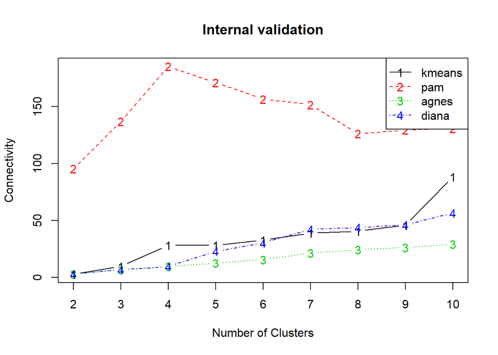

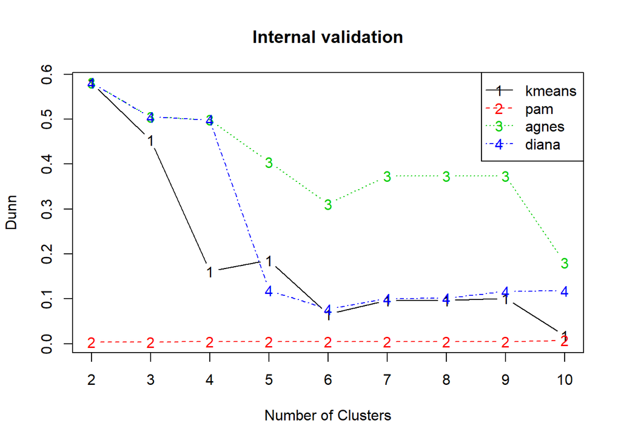

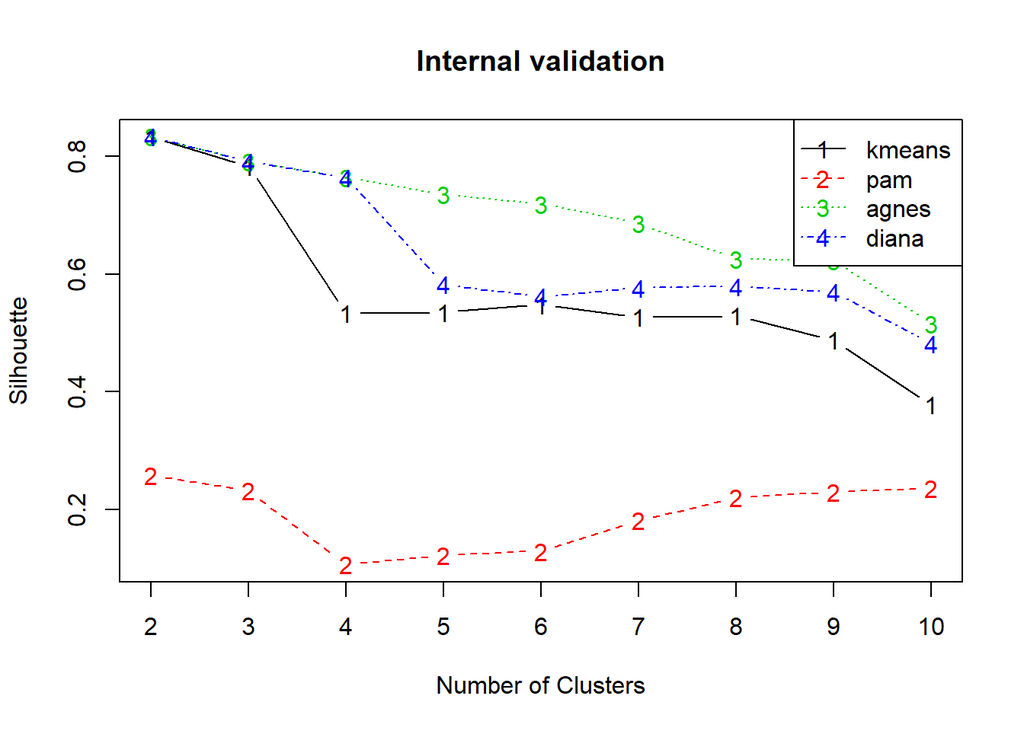

```r
plot(internal.cl)
```

#Things I learnt APN(Average Proportion of Non-overlap)-The APN measures the average proportion of observations not placed in the same cluster by clustering based on the full data and clustering based on the data with a single column removed.The APN is in the interval [0, 1], with values close to zero corresponding with highly consistent clustering results.

AD(Average Distance)- The AD measure computes the average distance between observations placed in the same cluster by clustering based on the full data and clustering based on the data with a single column removed. The AD has a value between zero and ∞, and smaller values are preferred.

ADM(Average Distance between Means)- The ADM measure computes the average distance between cluster centers for observations placed in the same cluster by clustering based on the full data and clustering based on the data with a single column removed. It has a value between zero and ∞,smaller values are prefered.

FOM(Figure of Merit)-The FOM measures the average intra-cluster variance of the observationsin the deleted column, where the clustering is based on the remaining (undeleted) samples. This estimates the mean error using predictions based on the cluster averages. The final score is averaged over all the removed columns, and has a value between zero and ∞, with smaller values equaling better performance.

```r
stability.cl = clValid(selected_data,
                nClust = 2:10,
                clMethods = c("kmeans","pam", "agnes", "diana"),
                maxitems = 1700, # specifies the number of cases considered
                validation = "stability")
## View stability metrics
summary(stability.cl)
```

```
##
## Clustering Methods:
##  kmeans pam agnes diana
##
## Cluster sizes:
##  2 3 4 5 6 7 8 9 10
##
## Validation Measures:
##                  2      3      4      5      6      7      8      9     10
##
## kmeans APN  0.0019 0.0350 0.0275 0.0712 0.0993 0.0117 0.0973 0.2344 0.0348
##        AD   2.9474 2.8429 2.6521 2.6402 2.5117 2.2597 2.2317 2.2178 2.0274
##        ADM  0.0277 0.1499 0.1714 0.3561 0.4722 0.2332 0.3915 0.6317 0.5225
##        FOM  1.0001 0.9833 0.9768 0.9775 0.9678 0.9665 0.9668 0.9677 0.9686
## pam    APN  0.0645 0.0930 0.1209 0.2361 0.2279 0.2290 0.1177 0.1571 0.2051
##        AD   2.7511 2.5655 2.5126 2.4526 2.2676 2.0949 1.8869 1.8160 1.7723
##        ADM  0.1808 0.2568 0.4001 0.6839 0.6765 0.6932 0.4260 0.4363 0.5081
##        FOM  0.9992 0.9862 0.9817 0.9807 0.9717 0.9699 0.9645 0.9535 0.9533
## agnes  APN  0.0012 0.0012 0.0019 0.0031 0.0081 0.0090 0.0086 0.0154 0.0330
##        AD   2.9474 2.8535 2.8063 2.7640 2.7287 2.6688 2.6320 2.6161 2.5970
##        ADM  0.0239 0.0357 0.0481 0.0628 0.0995 0.1055 0.0979 0.1187 0.1990
##        FOM  1.0001 0.9897 0.9908 0.9913 0.9900 0.9909 0.9569 0.9580 0.9569
## diana  APN  0.0012 0.0022 0.0272 0.0367 0.0463 0.0144 0.0231 0.0906 0.1699
##        AD   2.9474 2.8500 2.8054 2.6890 2.5440 2.3974 2.3701 2.3498 2.2643
##        ADM  0.0239 0.0349 0.1423 0.2234 0.2937 0.2015 0.2380 0.3645 0.5628
##        FOM  1.0001 0.9841 0.9829 0.9814 0.9714 0.9722 0.9733 0.9728 0.9725
##
## Optimal Scores:
##
##     Score  Method Clusters
## APN 0.0012 agnes  2
## AD  1.7723 pam    10
## ADM 0.0239 agnes  2
## FOM 0.9533 pam    10
```

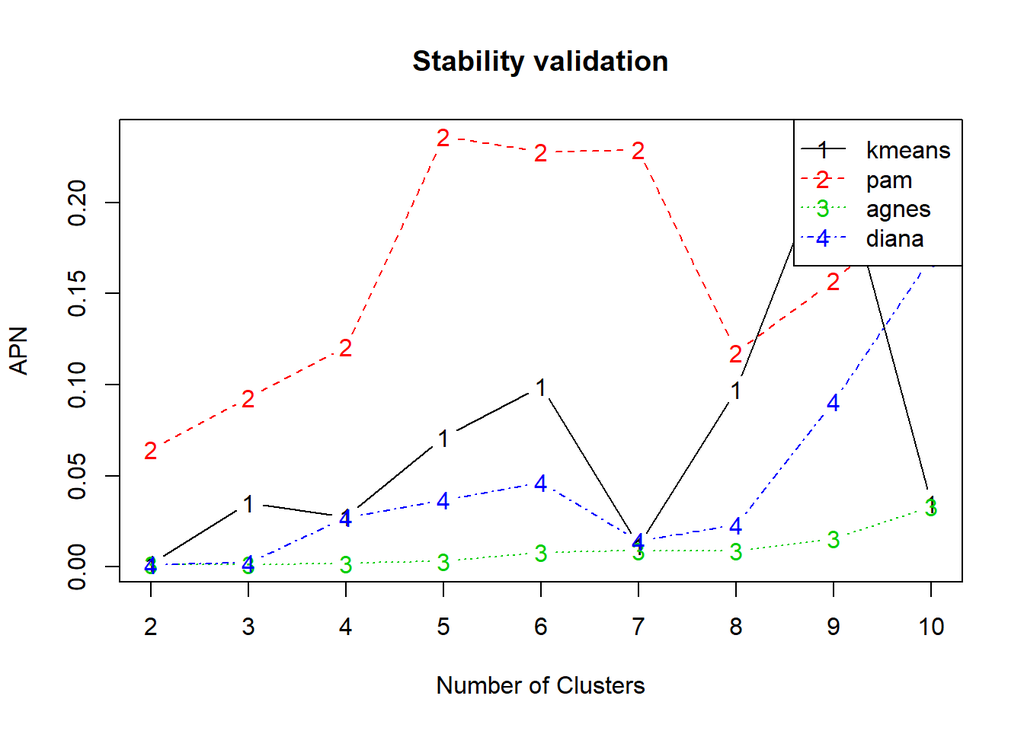

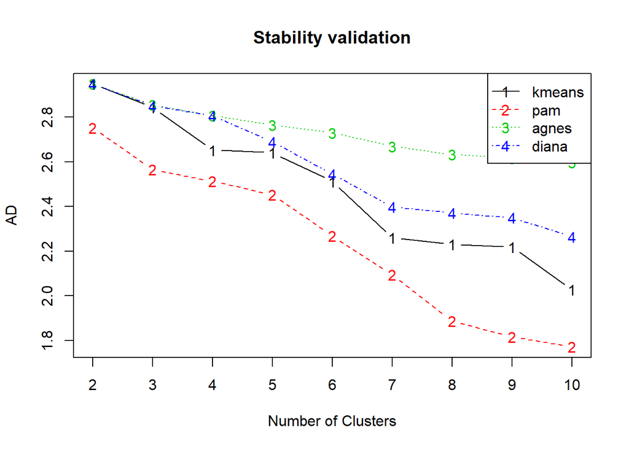

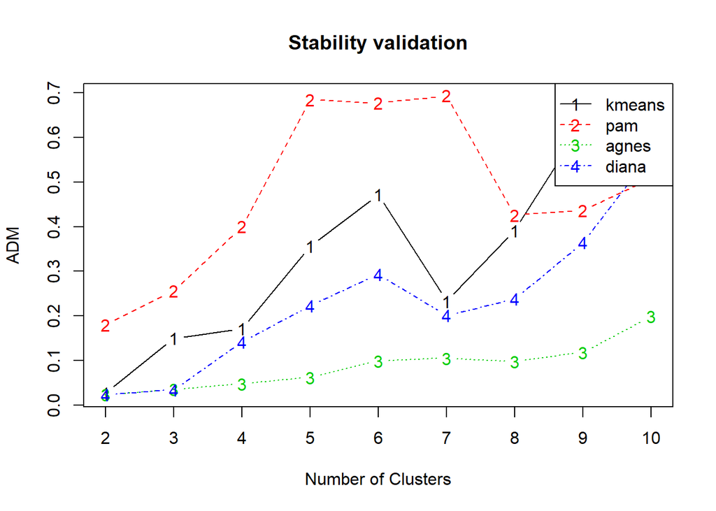

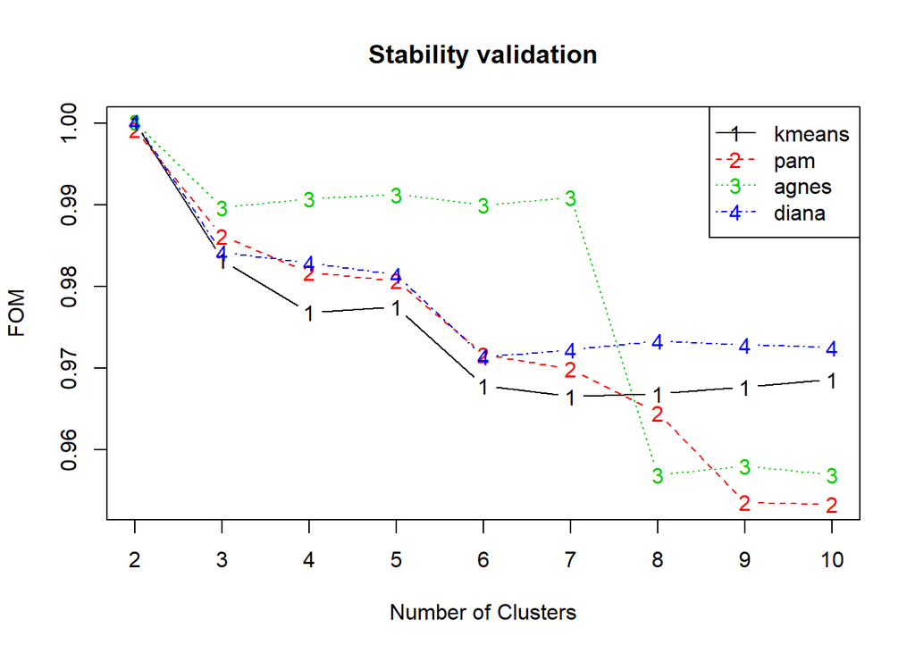

```r
plot(stability.cl)
```

#Things i learnt I chose the kmeans clustering algorithm since it took less computation times as compared to other algorithms and got good scores in the internal validation. As it is quite evident in the silhouette plot, that silhouette width is the highest for 2 clusters and acts as the local optima. Another method that can be used to choose the number of optimum clusters is the elbow plot method.

In this cell, I plotted the clusters as well as the silhouette plot for k means clustering algorithm . The average silhouette width turns out to be 0.3

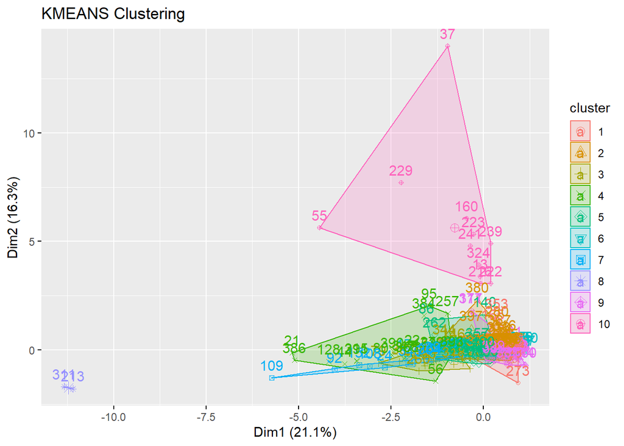

```r
compas = eclust(selected_data,
                    FUNcluster = "kmeans",
                    nboot = 200,
                    seed = 888)
```

```
##    cluster size ave.sil.width
## 1        1   58          0.29
## 2        2  168          0.39
## 3        3   13          0.23
## 4        4   20          0.05
## 5        5   68          0.23
## 6        6   11          0.35
## 7        7   15          0.18
## 8        8    2          0.45
## 9        9   34          0.25
## 10      10   11          0.02
```

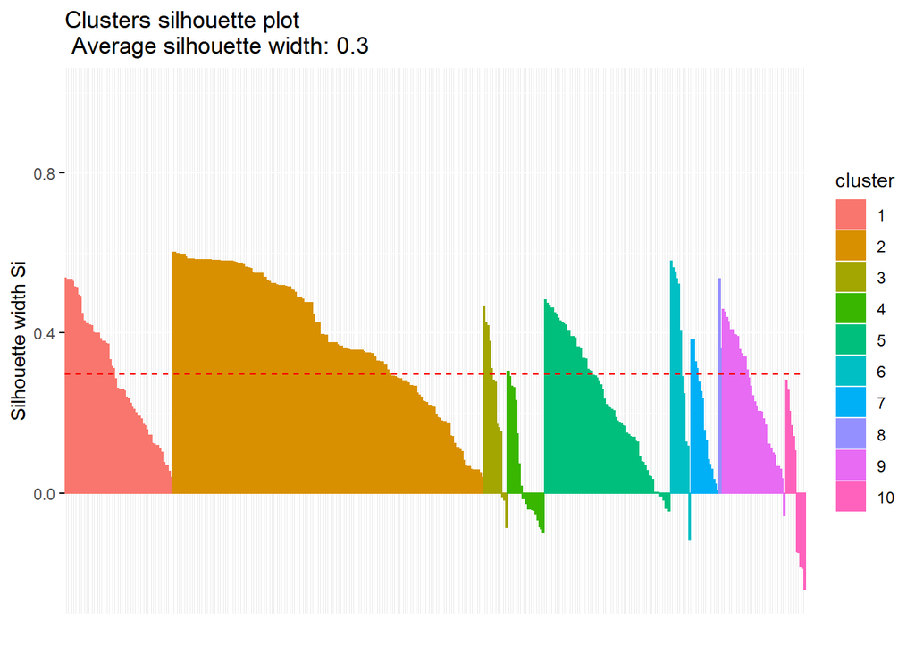

```r
# Silhouette plot
fviz_silhouette(compas)
```

#Couldnt plot the dendrogam plot with kmeans clustering algorithm

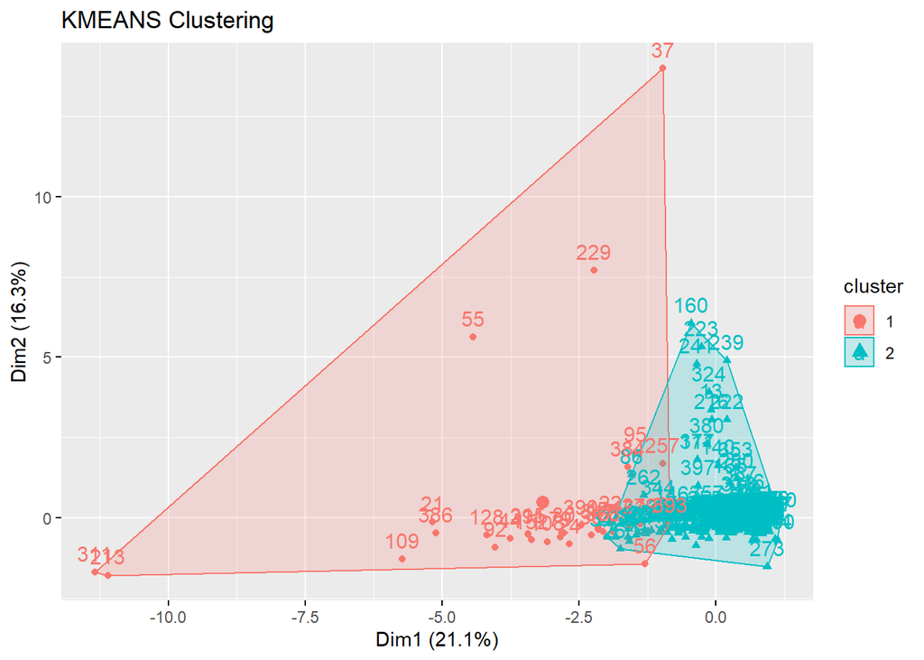

```r
compas = eclust(selected_data,
       FUNcluster = "kmeans",
       k = 2,
       hc_metric = "euclidean", hc_method = "ward.D2",
       seed = 888)
```

```
##   cluster size ave.sil.width
## 1       1   33         -0.15
## 2       2  367          0.65
```

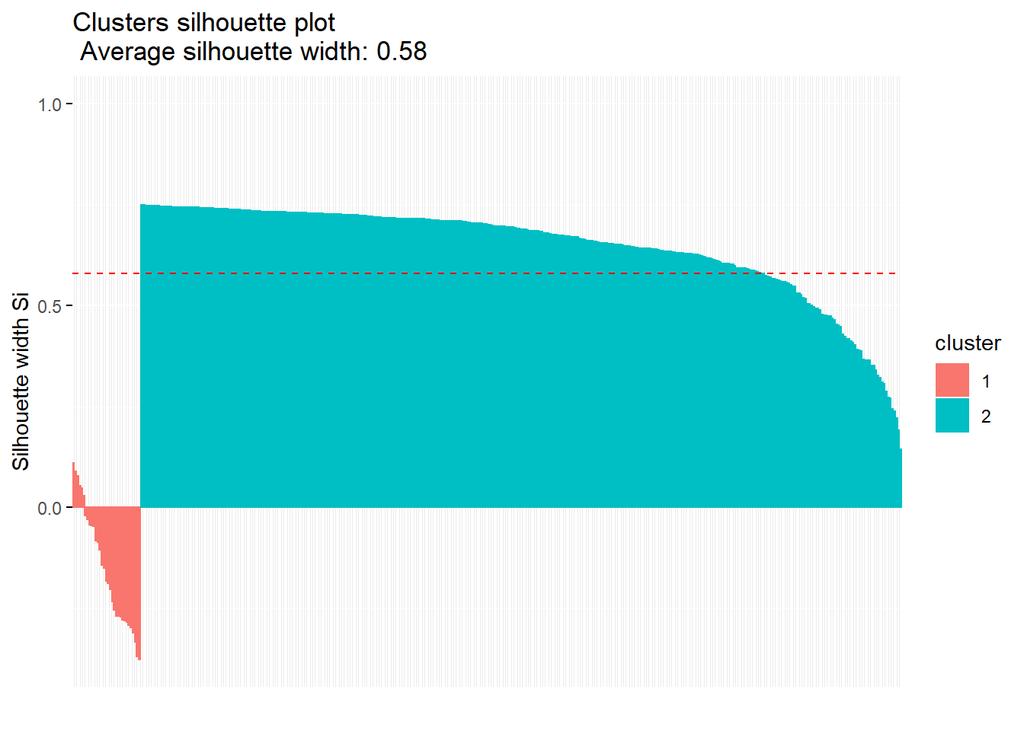

```r
# Silhouette plot
fviz_silhouette(compas)
```

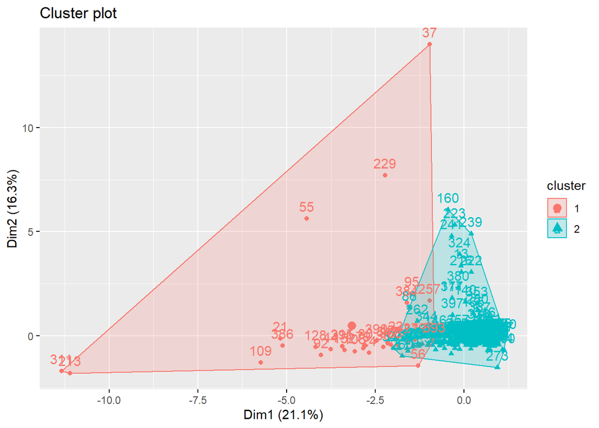

```r
# Dendrogam plot
#fviz_dend(compas)

# Plot cluster membership in PCA space
fviz_cluster(compas)
```

#Things I learnt UMAP is an algorithm for dimension reduction based on manifold learning techniques and ideas from topological data analysis. It provides a very general framework for approaching manifold learning and dimension reduction, but can also provide specific concrete realizations.

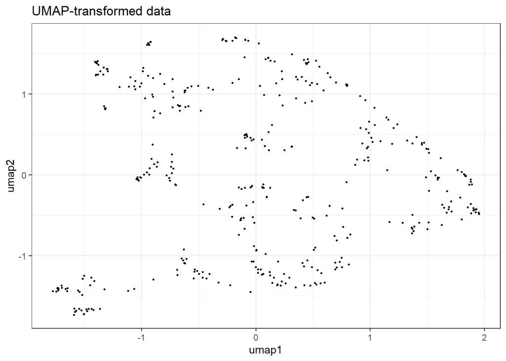

```r
umap.df = umap(selected_data, n_neighbors = 50, n_components = 2) %>% scale()
colnames(umap.df) = c("umap1", "umap2")
umap.df = as.data.frame(umap.df)

umap.plot = ggplot(umap.df, aes(umap1, umap2)) +
  geom_point(size = .5) +
  labs(title = "UMAP-transformed data") +
  theme_bw()
umap.plot
```

```r
selected_data = cbind(selected_data, umap.df)

## More components capture more information
umap4.df = umap(selected_data, n_neighbors = 50, n_components = 4) %>% scale()

## Cluster based on UMAP data
internal.cl = clValid(umap4.df,
                  nClust = 2:15,
                  clMethods = c("kmeans", "pam", "agnes", "diana"),
                  maxitems = 1700,
                  validation = "internal")
## View internal metrics
summary(internal.cl)
```

```
##
## Clustering Methods:
##  kmeans pam agnes diana
##
## Cluster sizes:
##  2 3 4 5 6 7 8 9 10 11 12 13 14 15
##
## Validation Measures:
##                            2       3       4       5       6       7       8       9      10      11      12      13      14      15
##
## kmeans Connectivity   0.0000  0.0000  0.0000  2.6135  2.6135  5.4675  5.4675 10.3544 15.5960 14.9365 17.6254 24.4663 33.9893 40.9052
##        Dunn           0.3021  0.2141  0.2632  0.0693  0.0877  0.0890  0.1017  0.0549  0.0652  0.0662  0.0662  0.0799  0.0799  0.0799
##        Silhouette     0.5189  0.5320  0.6079  0.6260  0.5816  0.6069  0.5856  0.6475  0.6414  0.6611  0.6647  0.6324  0.6167  0.6129
## pam    Connectivity   0.0000 10.8476 17.1306 19.7440 15.3567 20.6317 12.1159 14.9698 14.9698 14.9698 22.2448 28.7671 35.0242 39.5444
##        Dunn           0.1740  0.0159  0.0250  0.0306  0.0678  0.0397  0.0433  0.0440  0.0618  0.0718  0.0619  0.0619  0.0511  0.0511
##        Silhouette     0.4464  0.5115  0.5981  0.6118  0.5790  0.5718  0.5847  0.6113  0.6356  0.6608  0.6602  0.6442  0.6385  0.6133
## agnes  Connectivity   0.0000  0.0000  0.0000  1.8694  1.8694  4.7234  4.7234  7.2532 13.2722 13.2722 15.9611 20.2480 25.7734 26.7540
##        Dunn           0.3021  0.2141  0.2632  0.0693  0.0877  0.0890  0.0970  0.0970  0.0707  0.0718  0.0718  0.0808  0.0866  0.0866
##        Silhouette     0.5189  0.5320  0.6079  0.6255  0.5806  0.6059  0.5844  0.6373  0.6320  0.6544  0.6581  0.6310  0.6217  0.6225
## diana  Connectivity   0.0000  3.3635  6.2925  6.2925 11.6504 14.2639 17.1179 21.3452 21.3452 21.3452 27.3310 38.2952 38.2952 45.1361
##        Dunn           0.1075  0.0367  0.0432  0.0479  0.0523  0.0751  0.0758  0.0796  0.0846  0.1015  0.0647  0.0554  0.0554  0.0610
##        Silhouette     0.4255  0.4818  0.5406  0.5150  0.5136  0.5535  0.5744  0.6336  0.5532  0.4927  0.5347  0.5017  0.5444  0.5121
##
## Optimal Scores:
##
##              Score  Method Clusters
## Connectivity 0.0000 kmeans 2
## Dunn         0.3021 kmeans 2
## Silhouette   0.6647 kmeans 12
```

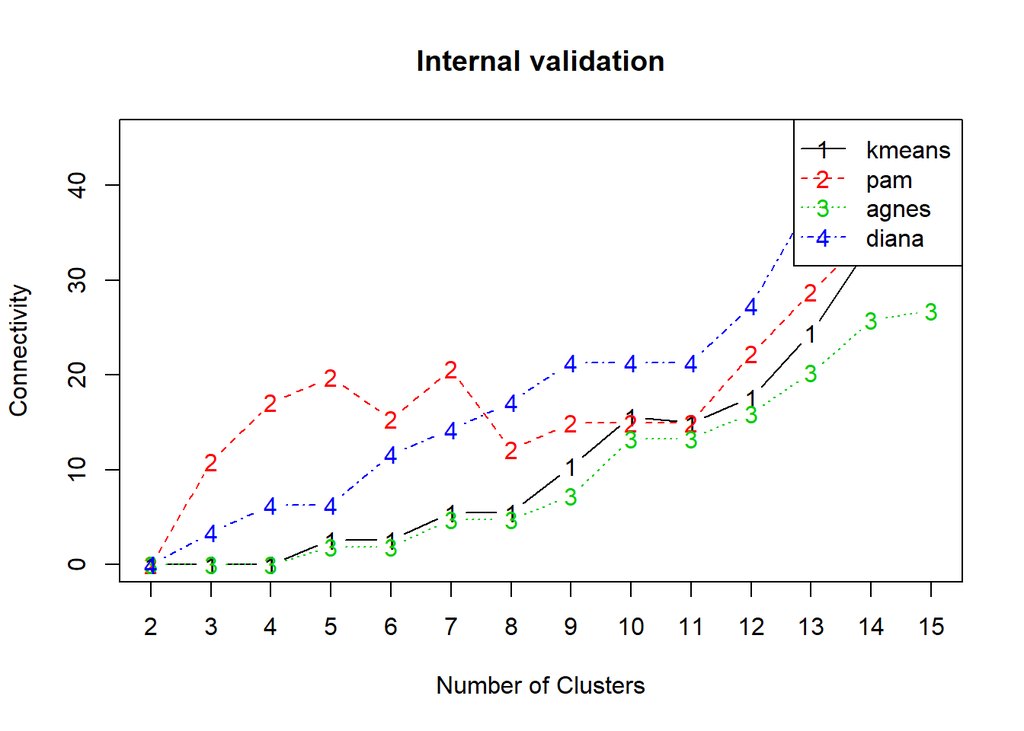

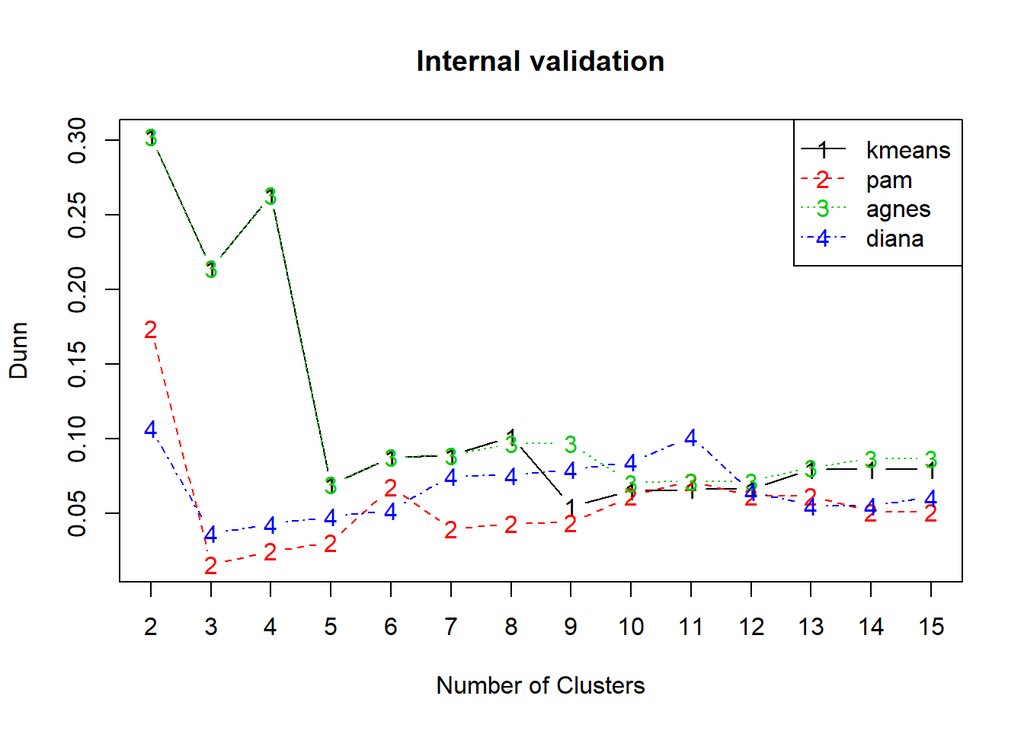

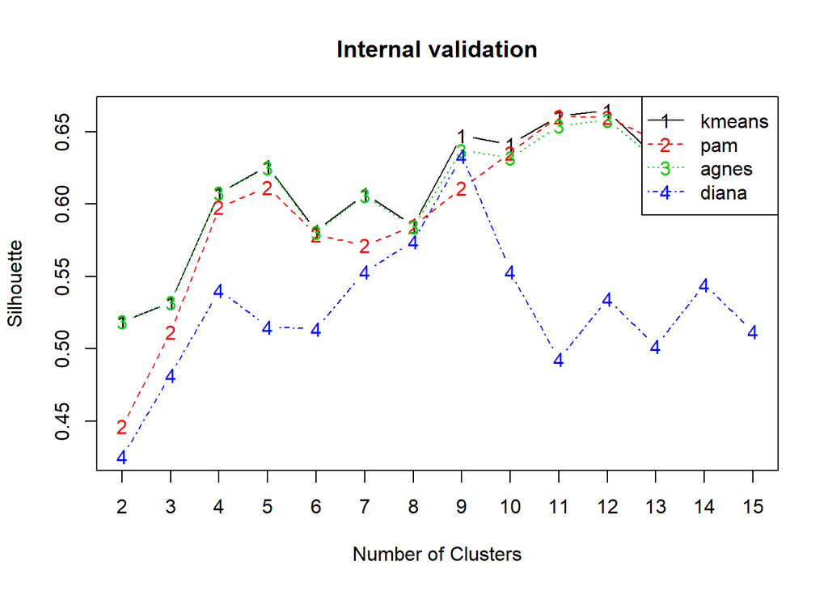

```r
plot(internal.cl)
```

```r
## Cluster based on UMAP data
stability.cl = clValid(umap4.df,
                  nClust = 2:15,
                  clMethods = c("kmeans", "pam", "agnes", "diana"),
                  maxitems = 1700,
                  validation = "stability")
## View internal metrics
summary(stability.cl)
```

```
##
## Clustering Methods:
##  kmeans pam agnes diana
##
## Cluster sizes:
##  2 3 4 5 6 7 8 9 10 11 12 13 14 15
##
## Validation Measures:
##                  2      3      4      5      6      7      8      9     10     11     12     13     14     15
##
## kmeans APN  0.1064 0.1368 0.0862 0.1038 0.1477 0.1568 0.1398 0.1124 0.0657 0.0505 0.0455 0.0625 0.0797 0.0823
##        AD   2.0597 1.5078 1.0034 0.8201 0.7297 0.6262 0.5474 0.4939 0.4088 0.3747 0.3380 0.3298 0.3213 0.2877
##        ADM  0.3830 0.5377 0.2485 0.2466 0.2636 0.2361 0.1850 0.1890 0.1192 0.0991 0.0718 0.0772 0.1020 0.0707
##        FOM  0.8880 0.7553 0.4718 0.3952 0.3538 0.2921 0.2592 0.2876 0.2215 0.2131 0.1721 0.1671 0.1661 0.1293
## pam    APN  0.0406 0.1477 0.0760 0.1441 0.0554 0.1451 0.1084 0.0771 0.0557 0.0423 0.0736 0.0796 0.0939 0.0805
##        AD   1.8919 1.6555 0.9950 0.8623 0.6292 0.6241 0.5352 0.4551 0.3899 0.3460 0.3388 0.3136 0.3004 0.2747
##        ADM  0.3830 0.8700 0.2198 0.3296 0.0866 0.2403 0.1680 0.1301 0.0825 0.0585 0.0808 0.0775 0.0808 0.0629
##        FOM  0.8606 0.7592 0.4687 0.4325 0.2854 0.2803 0.2829 0.2516 0.2008 0.1862 0.1839 0.1527 0.1506 0.1289
## agnes  APN  0.1064 0.1277 0.0860 0.0727 0.0884 0.1473 0.1249 0.1249 0.0873 0.0655 0.0598 0.0635 0.0753 0.0597
##        AD   2.0597 1.5232 1.0012 0.8107 0.7301 0.6656 0.5797 0.5114 0.4157 0.3816 0.3495 0.3403 0.3274 0.2950
##        ADM  0.3830 0.5499 0.2444 0.2277 0.2371 0.2777 0.2134 0.2107 0.1343 0.1171 0.0939 0.0911 0.1016 0.0641
##        FOM  0.8880 0.7746 0.4686 0.3936 0.3696 0.3594 0.3274 0.3038 0.2098 0.2012 0.1742 0.1709 0.1695 0.1381
## diana  APN  0.1503 0.2799 0.1344 0.2183 0.2803 0.2032 0.2019 0.1527 0.1624 0.1914 0.1481 0.1598 0.1521 0.1802
##        AD   2.1492 1.7555 1.1199 0.9836 0.9058 0.6900 0.6273 0.5521 0.4810 0.4500 0.3975 0.3857 0.3596 0.3519
##        ADM  0.6163 1.0248 0.4211 0.4982 0.5414 0.3193 0.3025 0.2664 0.1963 0.1856 0.1363 0.1512 0.1426 0.1459
##        FOM  0.8880 0.7553 0.4589 0.3956 0.3742 0.3620 0.3425 0.3267 0.2438 0.1976 0.1969 0.1947 0.1904 0.1873
##
## Optimal Scores:
##
##     Score  Method Clusters
## APN 0.0406 pam    2
## AD  0.2747 pam    15
## ADM 0.0585 pam    11
## FOM 0.1289 pam    15
```

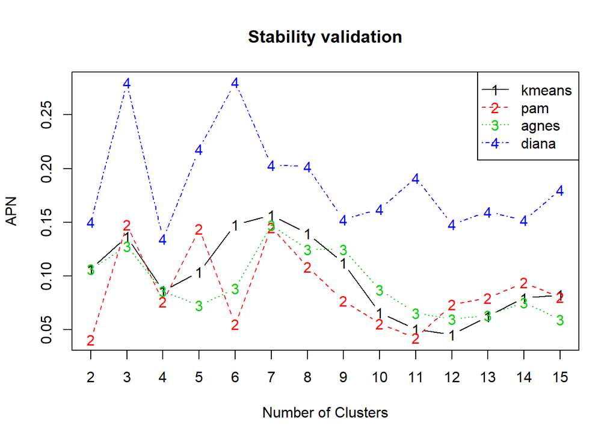

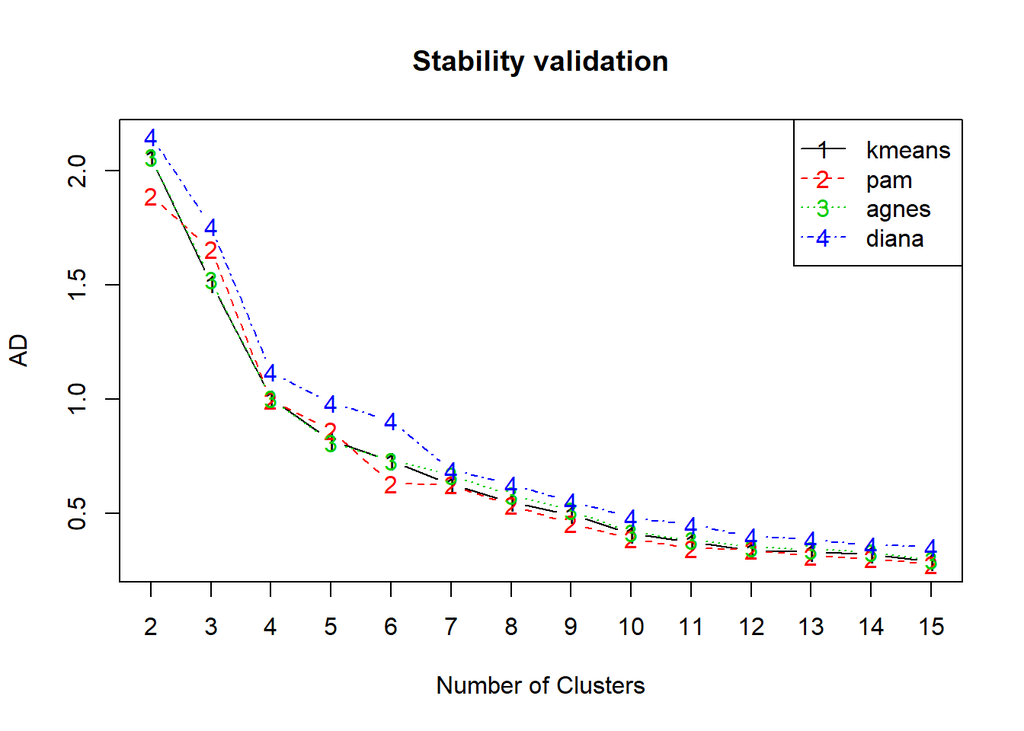

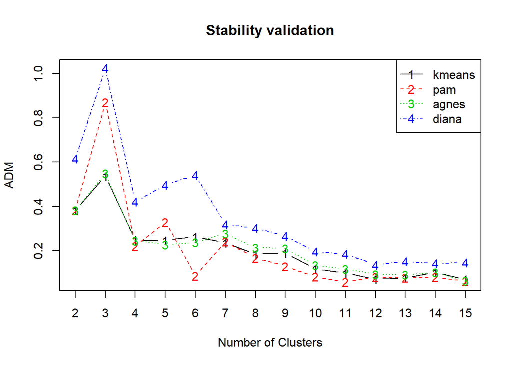

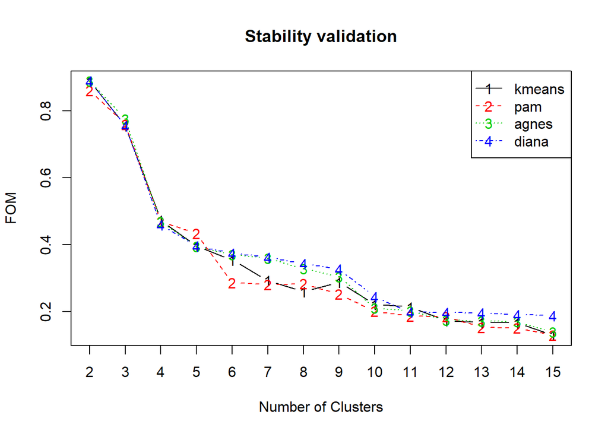

```r
plot(stability.cl)
```

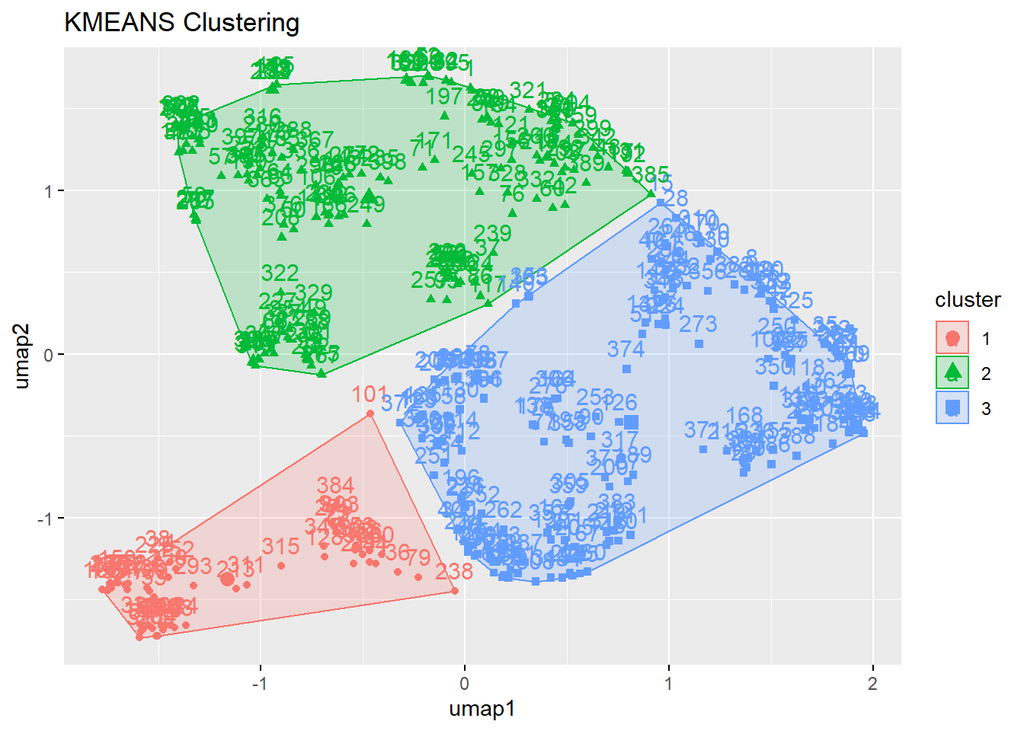

```r
## UMAP and kmeans
umap.compas.kmean = eclust(umap.df,
       FUNcluster = "kmeans",
       k = 3,
       seed = 888)
```

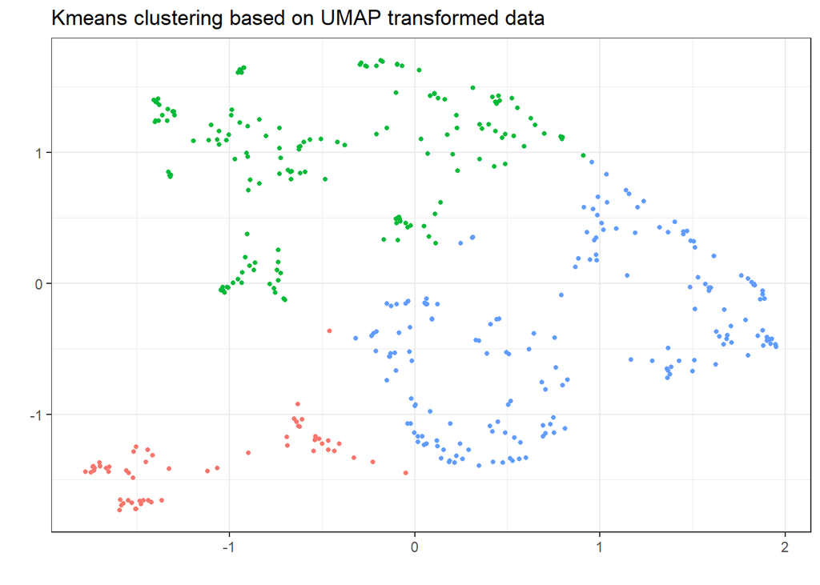

```r
selected_data = cbind(selected_data, cluster = as.factor(umap.compas.kmean$cluster))

km_umap.plot =
  ggplot(selected_data, aes(umap1, umap2, colour = cluster)) +
  geom_point(size = 1) +
  labs(title = "Kmeans clustering based on UMAP transformed data", x = "", y = "") +
  theme_bw() +
  theme(legend.position = "none")

km_umap.plot
```